# Итоговое задание: Тестим маркетинговую кампанию и делаем выводы

Мекшун Тихон, tdmekshun

## Задача

Нужно проверить эффективность и результаты нашей маркетинговой кампании. А именно, нужно выяснить:

1. Кто в итоге стал нашими главными клиентами? Видят ли в нас семейноориентированный-детский (family friendly) магазин?
2. Нам нужно выяснить, есть ли значимая разница между покупками онлайн и оффлайн? Может нам стоит стимулировать покупки через интернет если их очень мало?

### Загрузка данных и преобразование

```r
marketing = read.csv("~/shared/minor2_2022/1-Intro/hw2/marketing_campaign.csv")
```

## Предобработка

Загружаю все нужные библиотеки, меняю все типы char на фактор, для удобства преобразую дату.

```r
library(dplyr)
library(ggplot2)
library(coin)
library(rpart)
library(lubridate)
library(rpart.plot)

marketing = marketing %>% mutate_if(is.character, as.factor)
marketing$AcceptedCmp= as.factor(marketing$AcceptedCmp)
marketing$Complain = as.factor(marketing$Complain)
marketing$Response = as.factor(marketing$Response)
marketing$Dt_Customer=as.Date(marketing$Dt_Customer)
```

### Исследовательские вопросы и тесты

#### Первый иследовательский вопрос и тесты

Правда ли что, люди, у которых есть дети покупают у нас меньше всех?

H0: Люди с детьми и люди без детей покупают одинаково

H1: Люди с детьми покупают у нас меньше товаров, нежели люди без детей

1. Ответим на вопрос, есть ли вообще корреляция между наличием детей и колличеством покупок?

```r
kids_quest = marketing
kids_quest$Total = kids_quest$NumDealsPurchases+kids_quest$NumWebPurchases+kids_quest$NumStorePurchases
cor.test(kids_quest$Kidhome,kids_quest$Total)
```

```
##
##  Pearson's product-moment correlation
##
## data:  kids_quest$Kidhome and kids_quest$Total
## t = -15.283, df = 1332, p-value < 2.2e-16
## alternative hypothesis: true correlation is not equal to 0
## 95 percent confidence interval:
##  -0.4309806 -0.3396127
## sample estimates:
##        cor
## -0.3862437
```

Поразительно, мы получили обратную связь, причем значимую, так как p-value < 2.2e-16 . Иначе говоря, чем больше у пользователей детей, тем меньше они у нас покупают. Напрашиваются интересные выводы, но сначала сделаем таблицу.

```r
kids_group = kids_quest %>% group_by(Kidhome) %>% summarise(total = sum(Total))
kids_group
```

```
## # A tibble: 3 × 2
##   Kidhome total
##     <int> <int>
## 1       0 10820
## 2       1  5296
## 3       2   237
```

А вообще кто у нас вообще клиентская база? Люди с детьми или без?

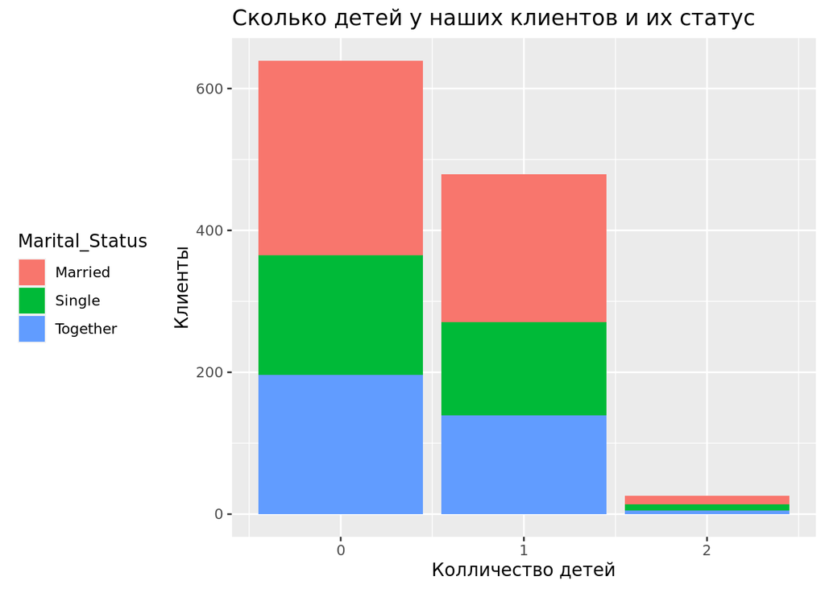

```r
kids_quest = kids_quest %>% filter(Marital_Status=='Together' | Marital_Status=='Single' | Marital_Status=='Married')
ggplot(kids_quest, aes(x = Kidhome, fill=Marital_Status)) +
  geom_bar() + xlab('Колличество детей') + ylab('Клиенты') + theme(legend.position = 'left') +labs(title='Сколько детей у наших клиентов и их статус')
```

#### Выводы

Наша маркетинговая кампания добилась таких результатов и позиционирования.

1. Чем больше у пользователей детей, тем меньше они у нас покупают
2. В нашей клиентской базе большинтсво людей не имеет детей
3. Большинство наших клиентов имеют статус “married”. Но так же много людей со статусом “одиночка”

Значит, наш магазин нельзя назвать семейноориентированным или детским.  
Почему? Всё очень просто, семьи с детьми мало покупают у нас.

#### Первый иследовательский вопрос и тесты

Правда ли что, покупок через интернет больше чем покупок оффлайн и эта разница статистически значима? Уровень значимости 0.05

H0: два средних значения совокупности равны

H1: два средних значения совокупности не равны

```r
t.test(marketing$NumWebPurchases,marketing$NumStorePurchases)
```

```
##
##  Welch Two Sample t-test
##
## data:  marketing$NumWebPurchases and marketing$NumStorePurchases
## t = -13.761, df = 2606.7, p-value < 2.2e-16
## alternative hypothesis: true difference in means is not equal to 0
## 95 percent confidence interval:
##  -1.824226 -1.369177
## sample estimates:
## mean of x mean of y
##  4.170915  5.767616
```

Хммм…разница есть и она действительно значима, теперь можно вывести таблицу, чтобы понять чего же больше

```r
buys = marketing %>% summarise(NumWebPurchases=sum(NumWebPurchases),NumStorePurchases=sum(NumStorePurchases), total = sum(NumWebPurchases)+sum(NumStorePurchases))
buys
```

```
##   NumWebPurchases NumStorePurchases total
## 1            5564              7694 13258
```

#### Выводы

Судя по всему, разница между покупками оффлайн и онлайн есть существенная разница. В данный момент лидируют покупки оффлайн.

### Предсказание отклика на кампанию

```r
tree_marketing = marketing
tree_marketing$day = wday(marketing$Dt_Customer)
```

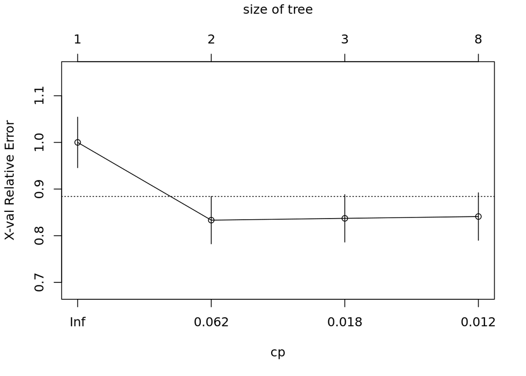

```r
set.seed(11)
train = sample_frac(tree_marketing, 0.8)
test = tree_marketing %>% anti_join(train)

tree = rpart(data = train , Response~AcceptedCmp+NumWebPurchases+NumDealsPurchases+NumStorePurchases+Recency+Teenhome, method = 'class')
plotcp(tree)
```

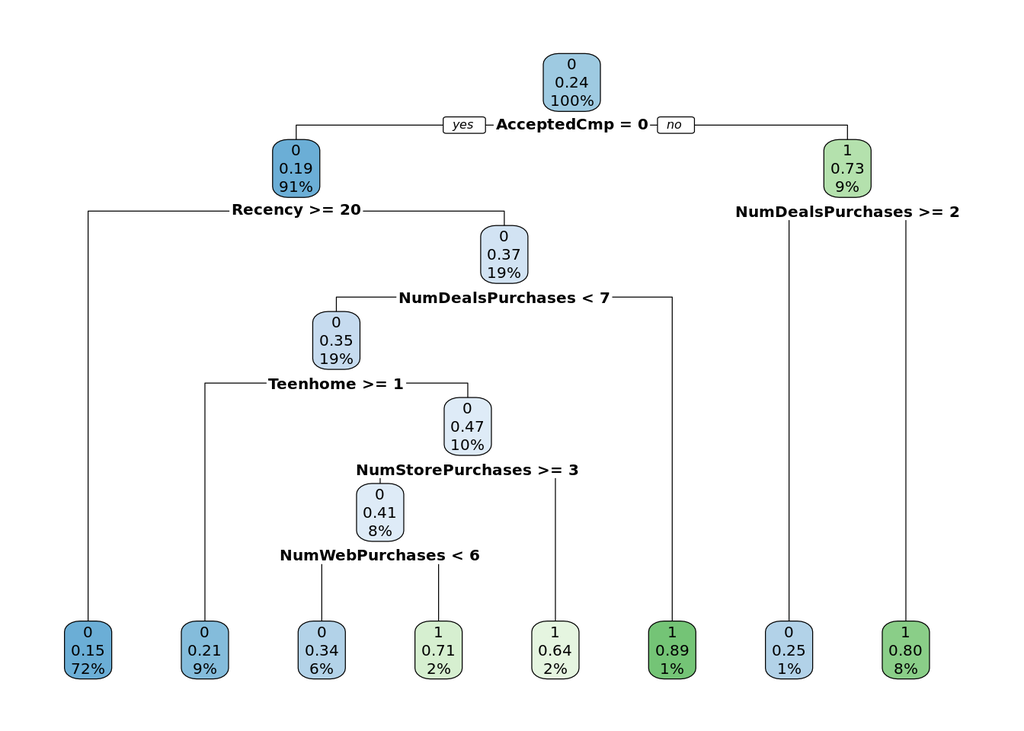

```r
rpart.plot(tree)
```

```r
pred_model = predict(tree, tree_marketing, type = 'class')

t = table(pred_model, tree_marketing$Response)
t
```

```
##
## pred_model   0   1
##          0 954 203
##          1  46 131
```

```r
pred_model_accuracy = (t[1,1] + t[2,2])/sum(t)
pred_model_accuracy
```

```
## [1] 0.8133433
```

#### Что я сделал?

Для того чтобы построить как можно более точную модель я:

1. Я отбросил те, признаки которые ТОЧНО не имеют связи с отликом на предложение компании. То есть ID (по понятным причинам), который может бросить на ложный след. Например, Complain (очень мало жалоб), можно считать выбросом. Так же стат.тест показал, что данная переменная незначима (нагружать дерево мне некчему)
2. Попытался определить самый важный признак, в данном случае AcceptedCmp, я понял это с помощью стат.тестов (p-value < 2.2e-16), существует определенная связь, а именно пользователи, откликнувшиеся на предыдущую кампанию, чаще откликаются и дальше. Что примечательно, если оставить только AcceptedCmp, то точность будет равна примерна 70%. Если “обрезать дерево” на CP=0.062, то как раз таки только AcceptedCmp и останется. 70% - хорошо, но можно и лучше.
3. Дальше, с помощью математики (стат.тесты) и логики я начал подбирать показательные переменные, для более точной модели. Так например, я обнаружил, что есть связь между принятием предложения и сколько человек не покупал дней в магазине. Зачем принимать предложение магазина, куда ты давно не заходил и чьими услугами ты не пользуешься? Проверяем через стат.тест - p-value = 2.15e-07.
4. После проведенных стат.тестов, оказалось, что все виды покупок статистически значимы

#### От чего я решил отказаться?

Были очень спорные моменты. Некоторые переменные были статистически значимыми, но прибавляли всего пару процентов и показались мне довольно сомнительными Например, дата рождения была на уровне значимости в 3 процента, да и сам признак мне показался нерепрезентативным. Я решил его исключить

Так я добился 80% точности. Стоит сказать, что я проверял на других сидах и процент примерно везде такой же.

#### Что можно улучшить?

Не смотря на мои старания, модель все равно показывает слишком много ложноотрицательных данных. Показывает, что клиент не принял предложение, хотя на самом деле принял.

#### Как модель работает на разные группы?

Возьмем самые многочисленные

```r
status = marketing
table(status$Marital_Status)
```

```
##
##   Absurd    Alone Divorced  Married   Single Together    Widow     YOLO
##        1        1      146      494      310      340       41        1
```

```r
Married = status %>% filter(Marital_Status=='Married')
Single = status %>% filter(Marital_Status=='Single')
Together = status %>% filter(Marital_Status=='Together')
```

Помолвленные

```r
set.seed(1)
train_m = sample_frac(Married, 0.8)
tree_m = rpart(data = train_m , Response~AcceptedCmp+NumWebPurchases+NumDealsPurchases+NumStorePurchases+Recency+Teenhome, method = 'class')
pred_model_m = predict(tree_m, Married, type = 'class')

tm = table(pred_model_m, Married$Response)
pred_model_accuracy = (tm[1,1] + tm[2,2])/sum(tm)
pred_model_accuracy
```

```
## [1] 0.8643725
```

Одиночки

```r
set.seed(2)
train_s = sample_frac(Single, 0.8)
tree_s = rpart(data = train_s , Response~AcceptedCmp+NumWebPurchases+NumDealsPurchases+NumStorePurchases+Recency+Teenhome, method = 'class')
pred_model_s = predict(tree_s, Single, type = 'class')

ts = table(pred_model_s, Single$Response)
pred_model_accuracy = (ts[1,1] + ts[2,2])/sum(ts)
pred_model_accuracy
```

```
## [1] 0.8193548
```

Вместе

```r
set.seed(55)
train_t = sample_frac(Together, 0.8)
tree_t = rpart(data = train_t , Response~AcceptedCmp+NumWebPurchases+NumDealsPurchases+NumStorePurchases+Recency+Teenhome, method = 'class')
pred_model_t = predict(tree_t, Together, type = 'class')

tt = table(pred_model_t, Together$Response)
pred_model_accuracy = (tt[1,1] + tt[2,2])/sum(tt)
pred_model_accuracy
```

```
## [1] 0.8882353
```

#### Итог

Лучше всего данная модель на людей из группы together, почти с 90% точностью!!!

## Общие выводы

Таким образом я ответил на задачи заказчика и проаналзировал результаты маркетинговой кампании, а так же сделал модель которая определяет с 80 точностью примет ли клиент предложение.

Самое главное:

Люди нас не воспринимают как фемели френдли магазин с детьми.

Между покупками онлайн и оффлайн есть существенная разница по колличеству. Причем люди выбирают чаще покупкку оффлайн.

Если клиент принял предложение в предыдущей кампании, то есть 70 процентная вероятность, что человек примет предложение и в компании. Иначе говоря, люди которые приняли предложение когда-либо активнее принимают другое предложение.